# Introduccion a R

## 3.1 Manipulacion de datos con dplyr

La libreria `dplyr` tiene varias funciones para manipulacion de datos que nos ayudan o limpiar, resumir, y conectar diferentes bases de datos

```r
# Si no tenemos la libreria requerimos instalarla:
# install.packages("dplyr")
# cargamos el paquete con la funcion library()
library(dplyr)
```

La libreria dplyr incorpora los pipes `%>%`, los cuales pueden conectar varias funciones a un objeto. esta es una alternativa para escribir varias funciones en una linea de codigo de una manera mas organizada.  
Por ejemplo:  
**F2(F1(x)) es igual a x %>% F1() %>% F2()**

Para empezar vamos a calcular la prevalencia por condado:

```r
PRRS %>%
  group_by(County) %>%
  summarise(N = n(), positivos = sum(Result)) %>%
  mutate(Prev = positivos/N) %>%
  arrange(desc(Prev))
```

```
## # A tibble: 28 x 4
##    County            N positivos  Prev
##    <chr>         <int>     <dbl> <dbl>
##  1 Story            37        30 0.811
##  2 Pottawattamie    51        34 0.667
##  3 Bremer           24        14 0.583
##  4 Hardin          105        50 0.476
##  5 Scott            57        22 0.386
##  6 Audubon          19         7 0.368
##  7 Grundy           34        11 0.324
##  8 Johnson          89        27 0.303
##  9 Wright          115        33 0.287
## 10 Keokuk           18         5 0.278
## # ... with 18 more rows
```

Ok, hemos usado muchas funciones conectadas para calcular la prevalencia, asi que lo explicamos por partes:  
- Primero ponemos el nombre de nuestra tabla.  
- La primera funcion `group_by()` nos agrupara las observaciones por una o mas variables que indiquemos.  
- La funcion `summarise()` realizara funciones a la variable que indiquemos estratificada por la variable por la cual estamos agrupando, p.e. cuando ponemos el argumento `sum(resultado)`, estamos sumando todos los resultados positivos por condado. `n()` simplemente nos regresa el numero de observaciones por grupo.  
- La funcion `mutate()` creara una nueva variable, aqui usamos las variables N y positivos creadas con la anterior funcion y calculamos la prevalencia aparente.

**Ejercicio:** Ahora intenta calcular la prevalencia por tipo de granja (variable farm_type):

```r
# Tu respuesta
```

```r
PRRS %>%
  group_by(Sex) %>%
  summarise(media_edad = mean(Age), mediana_edad = median(Age), SD_edad = sd(Age))
```

```
## # A tibble: 2 x 4
##   Sex   media_edad mediana_edad SD_edad
##   <chr>      <dbl>        <dbl>   <dbl>
## 1 H           35.9           30    24.7
## 2 M           19.8           17    15.1
```

## 3.2 Uniendo diferentes bases de datos:

```r
# Importamos la base de datos de attributos del predio
nodes <- read.csv("../Data/node_attrib.csv")
# Importamos la base de datos de movimientos
mov <- read.csv("../Data/network.csv")
# Obtenemos el numero de envios y arribos
Out <- mov %>%
  group_by(id_orig) %>%
  summarise(Envios = n()) %>%
  rename(id = id_orig)
In <- mov %>%
  group_by(id_dest) %>%
  summarise(Arribos = n()) %>%
  rename(id = id_dest)

# Unimos la base de datos de predios con el numero de envios/arribos
nodes <- nodes %>%
  left_join(Out, by ="id")
nodes <- nodes %>%
  left_join(In, by = "id")
```

```r
mov %>%
  group_by(id_orig) %>%
  summarise(N = n(), NUm.Cerdos = sum(pigs.moved)) %>%
  mutate(p.mov = NUm.Cerdos /N)
```

```
## # A tibble: 29 x 4
##    id_orig     N NUm.Cerdos p.mov
##      <int> <int>      <int> <dbl>
##  1       1    30       3528 118.
##  2       3    13       1087  83.6
##  3       4    15       1606 107.
##  4       5    33       3440 104.
##  5       6    11       1073  97.5
##  6       7     3        231  77
##  7       8    83       7620  91.8
##  8       9     6        609 102.
##  9      10     1        158 158
## 10      11     1        109 109
## # ... with 19 more rows
```

```r
mov %>%
  group_by(id_dest) %>%
  summarise(N = n(), NUm.Cerdos = sum(pigs.moved)) %>%
  mutate(p.mov = NUm.Cerdos /N)
```

```
## # A tibble: 26 x 4
##    id_dest     N NUm.Cerdos p.mov
##      <int> <int>      <int> <dbl>
##  1       1    13       1466 113.
##  2       2    33       3382 102.
##  3       4    35       3684 105.
##  4       5    14       1467 105.
##  5       6    47       4491  95.6
##  6       7   116      11034  95.1
##  7       8   195      19184  98.4
##  8      10     7        948 135.
##  9      12    21       1884  89.7
## 10      13     2        145  72.5
## # ... with 16 more rows
```

Algunos de las granjas no tuvieron envios o arribos y se marcan como NA, hay que cambiarlos a 0

```r
nodes[is.na(nodes)] <- 0
```

```r
nodes %>%
  dplyr::select(id, Envios) %>%
  arrange(desc(Envios)) %>%
  knitr::kable(format = "latex", booktabs = T)
```

[output not shown]

# 4. Graficando con R

El paquete base de R incluye varias herramientas para hacer basicamente cualqier tipo de grafico con nuestros datos. Existen otras librerias que ofrecen funciones para hacer graficos (`ggplot` es la mas popular), pero en lo personal yo hago todos mis graficos con el paquete base.

## Grafico de puntos (Scatterplot)

Uno de los graficos mas basicos que podemos hacer son los graficos scatterplot, son utiles cuando queremos ver la relacion entre dos variables continuas.

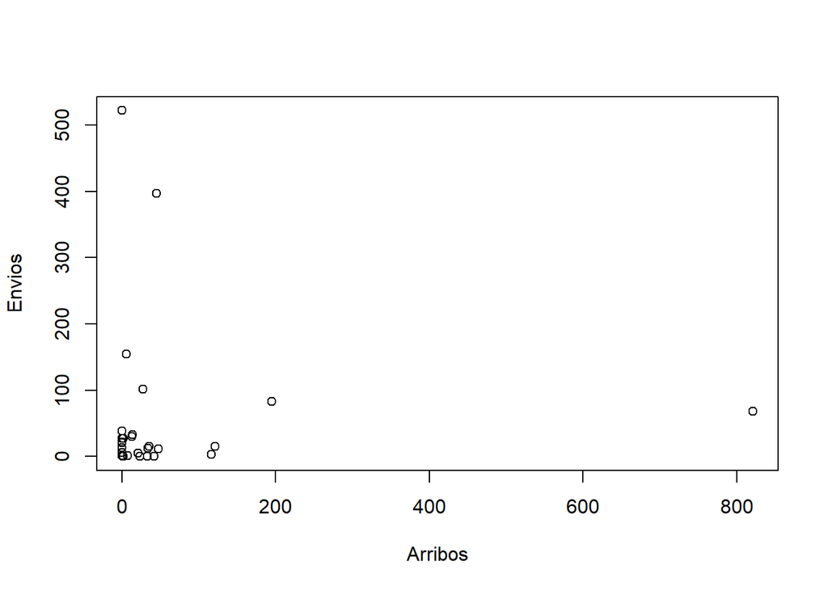

```r
plot(Envios~Arribos, data = nodes)
```

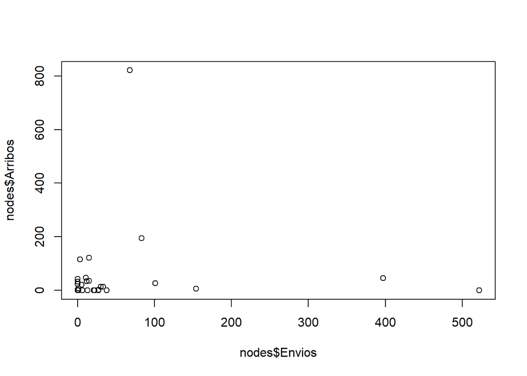

```r
plot(nodes$Envios, nodes$Arribos)
```

## 4.1 Grafico de pay

Los graficos de pay nos sirven para mostrar proporciones, por ejemplo a continuacion haremos un grafico que represente los porcentajes de animales positivos por tipo de granja.  
Para seleccionar una variable dentro de una data.frame, utilizamos el caracter `$`, por ejemplo, si queremos accesar a la variable tipo de granja (farm_type) de la tabla PRRS, usamos `PRRS$farm_type`

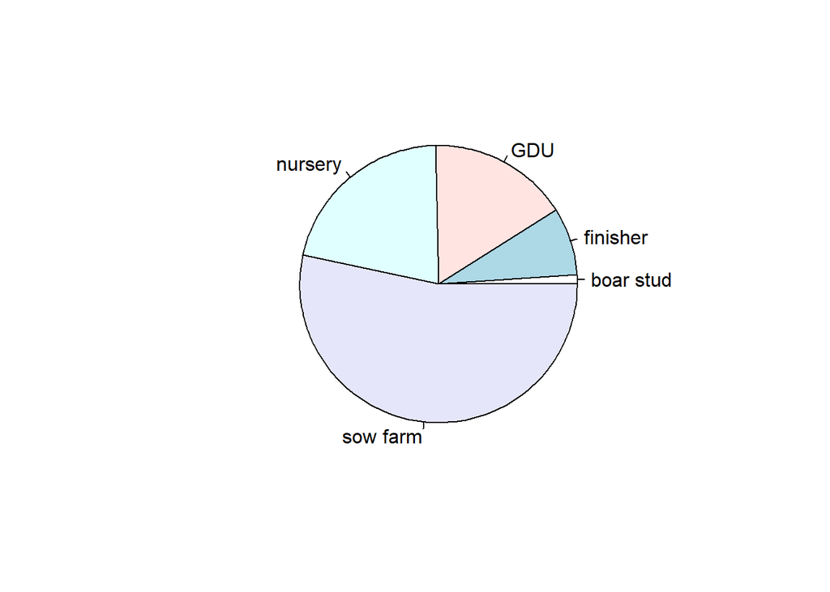

```r
# Primero creamos una tabla para el resultado por sexo del animal
TM <- table(PRRS$farm_type, PRRS$Result)
# Despues usaremos la segunda columna de nuestra tabla, que contiene los positivos unicamente
pie(TM[,2])
```

## 4.2 Boxplots

En mi opinion los boxplots son los graficos mas utiles para ver la distribucion de una variable continua. Como todas las funciones en R, la funcion `boxplot()` tiene varios argumentos que podemos proporcionar, pero si solo le proporcionamis el nombre de una variable continua, nos regresara un boxplot un poco aburrido de la variable

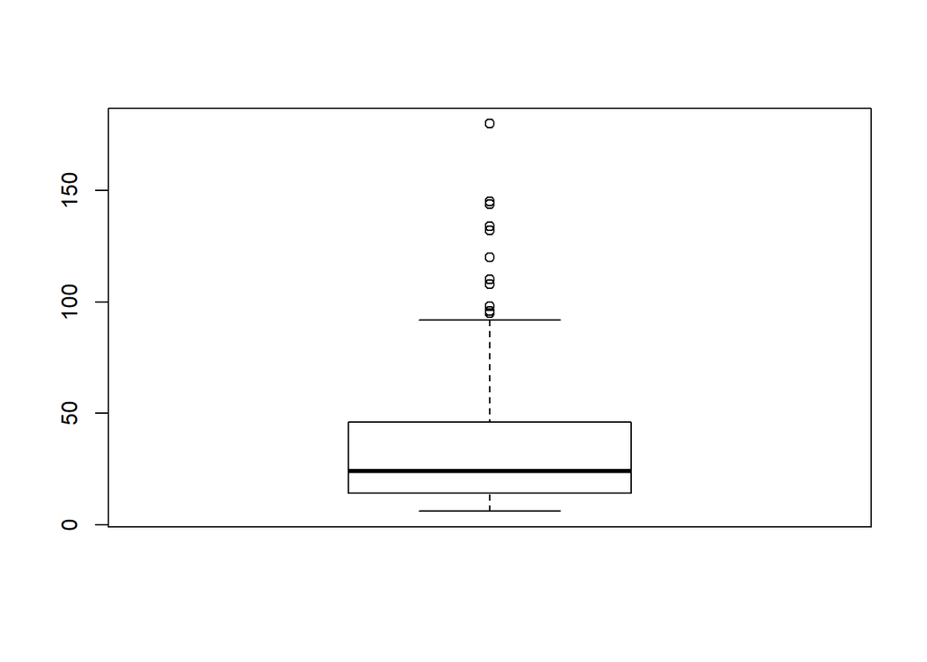

```r
boxplot(x = PRRS$Age)
```

Podemos poporcionar differentes argumentos para mejorar nuestra grafica, asi como estratificar nuestra variable por otra variable categorica:

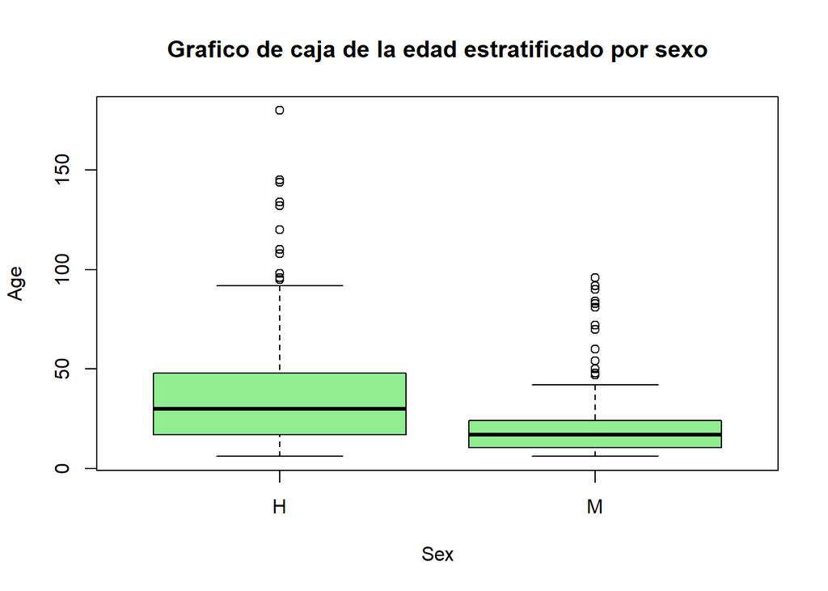

```r
boxplot(Age~Sex, data = PRRS, col = "lightgreen",
        main = "Grafico de caja de la edad estratificado por sexo")
```

Las funciones de base para graficos de R son muy flexibles, mientras mas las utilices mas te daras cuenta de todos los argumentos que tienen para ayudarte a hacer graficos mas informativos y personalizables, la mayoria de los argumentos son intuitivos, pero puedes ver que hace cada uno en la documentacion de la funcion o en la opcion de autocompletar.

## 4.3 Graficos de barras

Para el siguiente grafico utilizaremos mas argumentos, vamos a estratificar el resultado por el sexo del animal:

[figure not shown]

```r
# Primero creamos una tabla de los resultados por tipo de granja
TM <- table(PRRS$Result, PRRS$Sex)
# Despues usaremos la duncion par() para incrementar los margenes:
par(mar = c(2, 6, 2, 2))
barplot(TM[, order(colSums(TM), decreasing = T)], beside = T, horiz = T,
        las = 2, main = "Resultados por tipo de granja", col = c("green", "red"),
        legend = rownames(TM))
```

**Ejercicio:** Haz un grafico de barras estratificando el resultado por el tipo de granja:

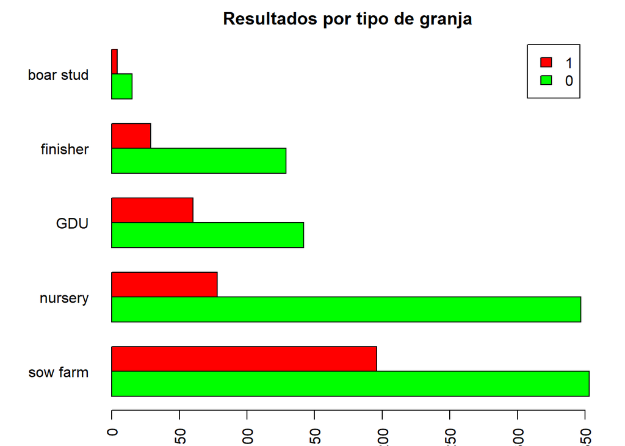

```r
# Primero creamos una tabla de los resultados por tipo de granja
TM <- table(PRRS$Result, PRRS$farm_type)
# Despues usaremos la duncion par() para incrementar los margenes:
par(mar = c(2, 6, 2, 2))
barplot(TM[, order(colSums(TM), decreasing = T)], beside = T, horiz = T,
        las = 2, main = "Resultados por tipo de granja", col = c("green", "red"),
        legend = rownames(TM))
```

## 4.4 Graficos temporales.

Para hacer un grafico temporal primero tenemos que manipular un poco las fechas para que R pueda reconocerlas y despues veremos el numero de movimientos por semana

```r
mov$date <- as.Date(mov$date, "%m/%d/%y")
# Creamos una variable para identificar la semana del año
mov$week <- format(mov$date, "%V")
```

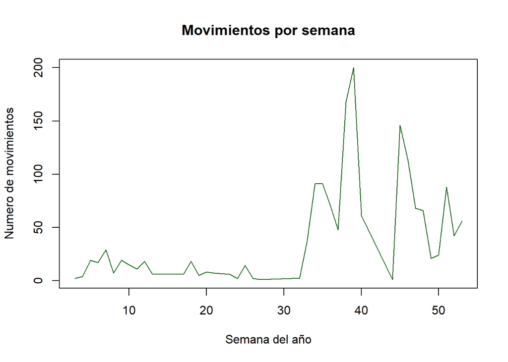

```r
mw <- mov %>%
  group_by(week) %>%
  summarise(N = n())

plot(N~week, data = mw, type = "l", col = "darkgreen", main = "Movimientos por semana", xlab = "Semana del año", ylab = "Numero de movimientos")
```

Regresar